# Question

A ship sailed 7.7 miles in a direction of 38° North of East. The ship turned and sailed 6.6 miles in a direction 61° North of East.

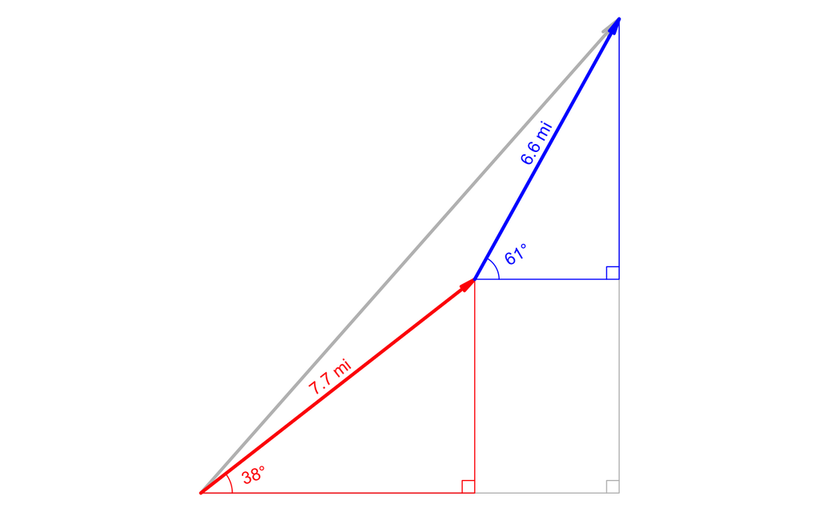

The ship’s captain suffers a terrible accident. The first officer radios for help and sets anchor, waiting for help while administering first aid.

A helicopter, starting where the ship started, wishes to fly directly to the ship. What direction ($\theta$ rounded to nearest degree) and distance ($r$ rounded to nearest tenth of a mile) should the helicopter fly?

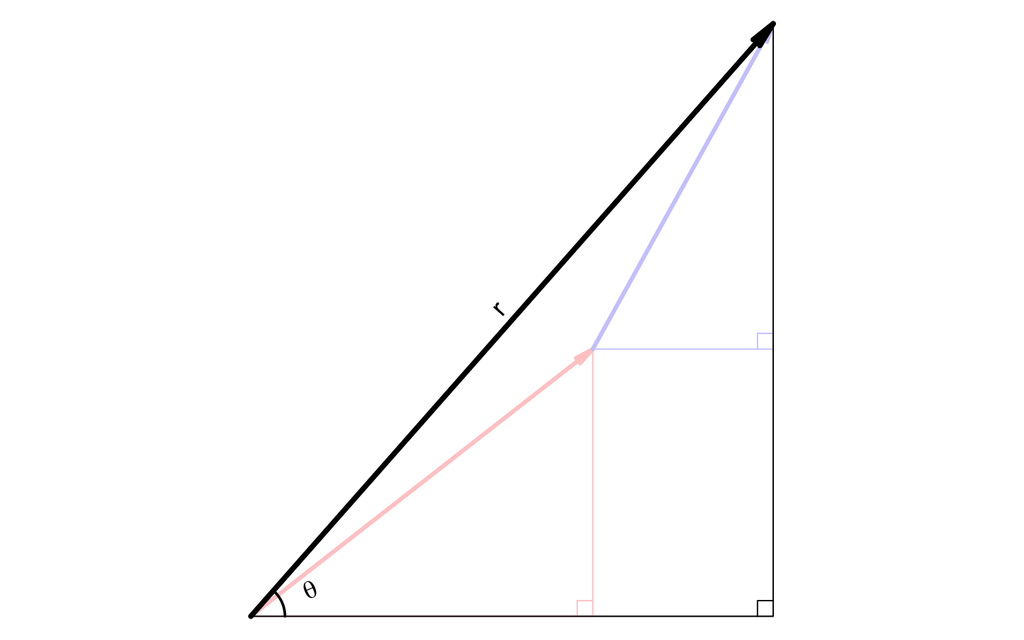

- The direction: $\theta =$ ##ANSWER1##
- The distance: $r =$ ##ANSWER2##

## Answerlist

- 43
- 44
- 45
- 46
- 47
- 48
- 49
- 50
- 14
- 14.1
- 14.2
- 14.3
- 14.4
- 14.5
- 14.6
- 14.7

# Solution

Start by naming some lengths (the legs of the two small triangles).

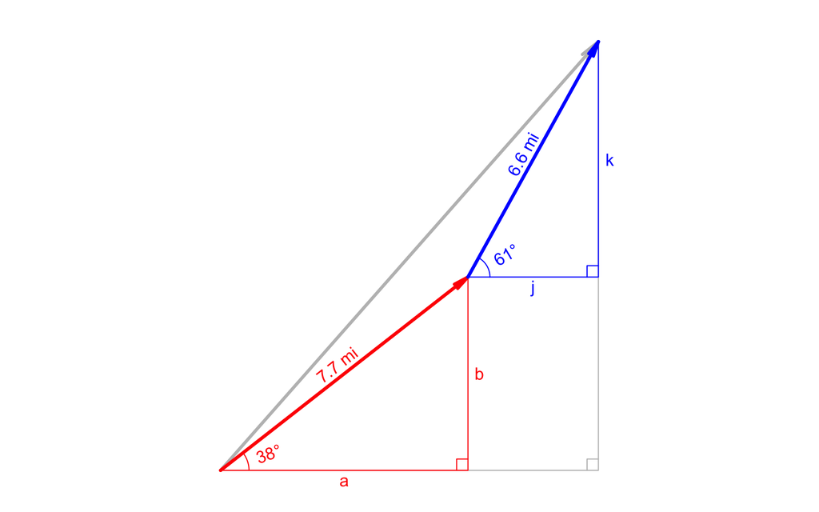

Evaluate $a$, $b$, $j$, and $k$. Remember to set your calculator to DEGREE MODE.

$$a ~=~ 7.7 \cos(38^\circ) ~=~
6.0676828$$
$$b ~=~ 7.7 \sin(38^\circ)
~=~ 4.7405934$$
$$j ~=~ 6.6
\cos(61^\circ) ~=~ 3.1997435$$
$$k ~=~
6.6 \sin(61^\circ) ~=~ 5.7724901$$

Name the lengths of the large triangle.

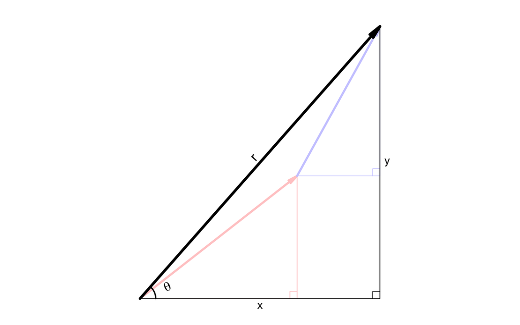

Calculate $x$ and $y$.

$$x~=~6.0676828+3.1997435~=~9.2674263$$
$$y~=~4.7405934+5.7724901~=~10.5130834$$
Calculate $\theta$. Remember to set your calculator to DEGREE MODE.

$$\theta ~=~
\arctan\left(\frac{10.5130834}{9.2674263}\right) ~=~ 48.6033841^\circ
~\approx~ 49^\circ$$

Calculate $r$ by using [Pythagorean Theorem](https://en.wikipedia.org/wiki/Pythagorean_theorem).

$$r ~=~ \sqrt{9.2674263^2+10.5130834^2}
~=~ 14.0146392 ~\approx~ 14 ~\mathrm{mi}$$

Instead of using Pythagorean Theorem, you could have used trigonometry.

$$r ~=~
\frac{9.2674263}{\cos(48.6033841^\circ)} ~=~
\frac{10.5130834}{\sin(48.6033841^\circ)} ~=~ 14.0146392 ~\approx~
14~\mathrm{mi}$$

# Meta-information

extype: cloze exclozetype: schoice|schoice exsolution: 00000010|10000000 exname: polar_vector_add_simple